# PDD M2S1 Analysis - 5% variance in police force baselines

# 1 Parameterisation

The intent of this section is to give an overview of the paremeterisation used in the simulation, for example what parameters varied, what remained fixed, and then to give a visual overview.

# 2 Base parameters

## 2.1 Police forces

| PoliceForceID | UsesPDD | Population | ParticipantCount | PersistentOffenderFraction |
| --- | --- | --- | --- | --- |
| PF1 | True | 527000 | 193 | 1 |
| PF2 | True | 2145000 | 787 | 0 |
| PF3 | True | 2930000 | 1075 | 0 |
| PF4 | False | 2820000 | 1035 | 0.5 |
| PF5 | False | 1376000 | 505 | 0.5 |
| PF6 | False | 1140200 | 418 | 0.5 |
| PF7 | True | 1720000 | 631 | 0 |
| PF8 | True | 675700 | 248 | 0 |
| PF9 | False | 1423065 | 522 | 0.5 |
| PF10 | False | 1790000 | 657 | 0.5 |

[output cut: 8 more lines]

Offenders fall into two categories:

1. Group 1: Low level offenders
2. Group 2: Persistent offenders (typically drug dependent)

In the above table we characterise this using the parameter `PersistentOffenderFraction`.

It can be observed that for police forces that do not implement PDD, this value is 0.5 as it assumed that these “control” forces have a 50/50 split of offender types. Police force PDD schemes usually target one or the other offender group. For this reason if a force targets Group 1, it is assumed that there `PersistentOffenderFraction` is 0 and if a force targets Group 2 it is assumed that their `PersistentOffenderFraction` is 1. Thus the above table captures both the semantics of whether a police force uses PDD and which offender group it targets.

From the above we can derive the following information:

| PDDType | PoliceForces | N |
| --- | --- | --- |
| Group 2 | PF1 PF17 | 2 |
| Group 1 | PF2 PF3 PF7 PF8 PF11 PF12 PF14 PF15 | 8 |
| NONE | PF4 PF5 PF6 PF9 PF10 PF13 PF16 PF18 | 8 |

## 2.2 Effects

There are three outcome effects modelled at the participant level:

We assume force level variation of the baseline event and a fixed effect of PDD. Furthermore the baseline rate of `HospitalEventCount` is different for Group 1 and Group 2 offenders. The parameters are as follows:

| Outcome | Baseline G1 | Baseline G2 | Impact G1 | Impact G2 |
| --- | --- | --- | --- | --- |
| ReoffendedWithinYear | 0.25 ± 0.01 % | 0.25 ± 0.01 % | -0.03 | -0.03 |
| EnteredDrugTreatment | 0.1 ± 0.01 % | 0.1 ± 0.01 % | 0.05 | 0.05 |
| HospitalEventCount | 0.0248 ± 0.01 % | 0.123 ± 0.01 % | -0.00248 | -0.0184 |

At the present time the impact is identical for groups 1 and 2 for `ReoffendedWithinYear` and `EnteredDrugTreatment` outcomes.

Variability is added to the baseline values per force from a normal distribution constructed so that the truncated 99.999% tails coincide with the %, as specified in the table above.

A given participant then receives an effect probability according to:

$$\text{EffectProbability} = \text{ForceBaseline} + \text{UsesPDD} \times ((1-\text{IsPersistentOffender}) \times \text{ImpactG1} + \text{IsPersistentOffender} \times \text{ImpactG2})$$

Where:

$$\text{UsesPDD} \in \{0,1\}$$

denotes the participants PDD status (inherited from force) and:

$$\text{IsPersistentOffender} \in \{0,1\}$$

denote the participant group status.

# 3 Simulation

We generate 1000 random datasets and fit the following models.

| Name | ModelFunction | Formula | Family |
| --- | --- | --- | --- |
| ReoffendedWithinYear | glmer | ReoffendedWithinYear ~ UsesPDD + PersistentOffender + (1 \| PoliceForceID) | binomial |
| EnteredDrugTreatment | glmer | EnteredDrugTreatment ~ UsesPDD + PersistentOffender + (1 \| PoliceForceID) | binomial |
| HospitalEventCount | glmmTMB | HospitalEventCount ~ UsesPDD + PersistentOffender + (1 \| PoliceForceID) | nbinom2 |

The model with `UsesPDD` as a predictor variable and a random intercept term `(1|PoliceForceID)` is a mixed-effects logistic regression model that examines the relationship between police diversion and the likelihood of reoffending within a year, while taking into account the variation in the baseline reoffending probability across different police forces. The response variables are defined as follows:

In this model, `randomDataset` is the dataset that contains the variables of interest (`ReoffendedWithinYear`, `UsesPDD`, and `PoliceForceID`). The `family` argument specifies that a binomial model should be used since the response variable is binary. The random intercept term `(1|PoliceForceID)` allows for variation in the baseline reoffending probability across different police forces.

## 3.1 Results Summary

The table below shows the proportion of models out of 1000 that found the respective outcome significant at the 5% level.

| Outcome | AllForces_1000 | First6Forces_1000 |
| --- | --- | --- |
| EnteredDrugTreatment | 1 | 0.989 |
| HospitalEventCount | 0.1791497975708502 | 0.1043663471778488 |
| ReoffendedWithinYear | 0.797 | 0.506 |

## 3.2 Results AllForces

### ReoffendedWithinYear

#### 3.2.0.1 Significance proportions

The figure below shows the histogram of the UsesPDD fixed effect significance:

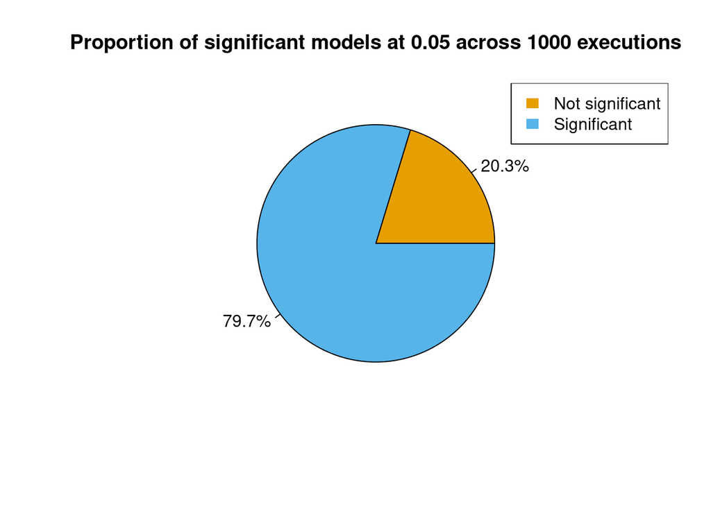

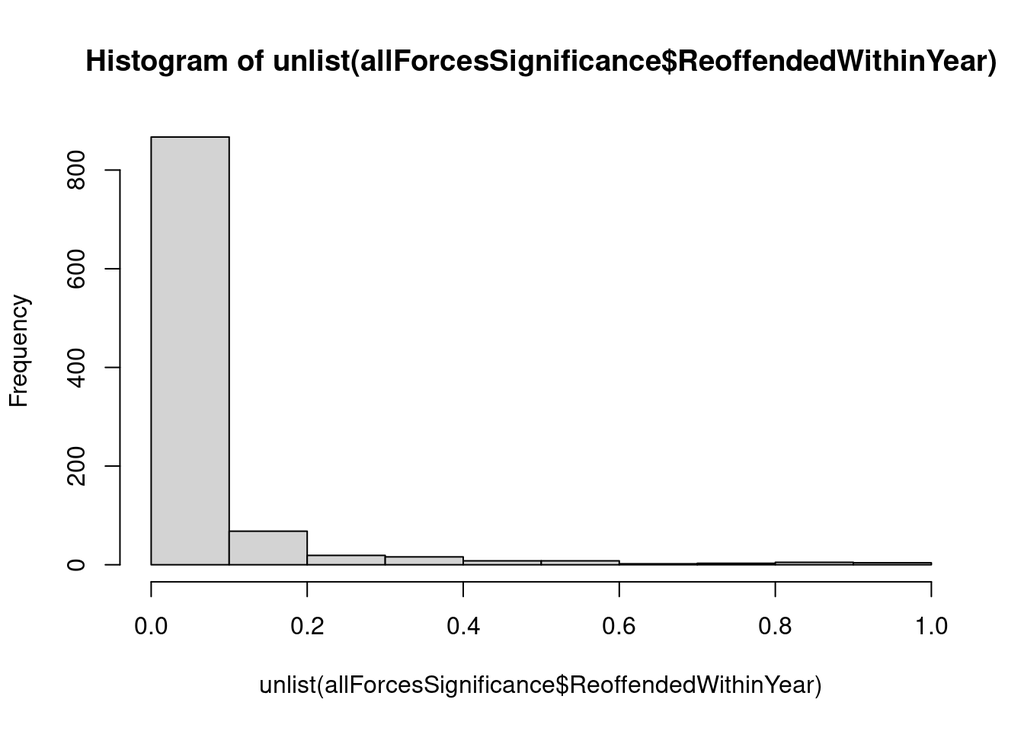

```
##      Min.   1st Qu.    Median      Mean   3rd Qu.      Max.
## 0.0000000 0.0005229 0.0044927 0.0499595 0.0315352 0.9348858
```

#### 3.2.0.2 Most significant model

```
## Length  Class   Mode
##      0   NULL   NULL
```

#### 3.2.0.3 Least significant model

```
## Length  Class   Mode
##      0   NULL   NULL
```

### EnteredDrugTreatment

#### 3.2.0.4 Significance proportions

The figure below shows the histogram of the UsesPDD fixed effect significance:

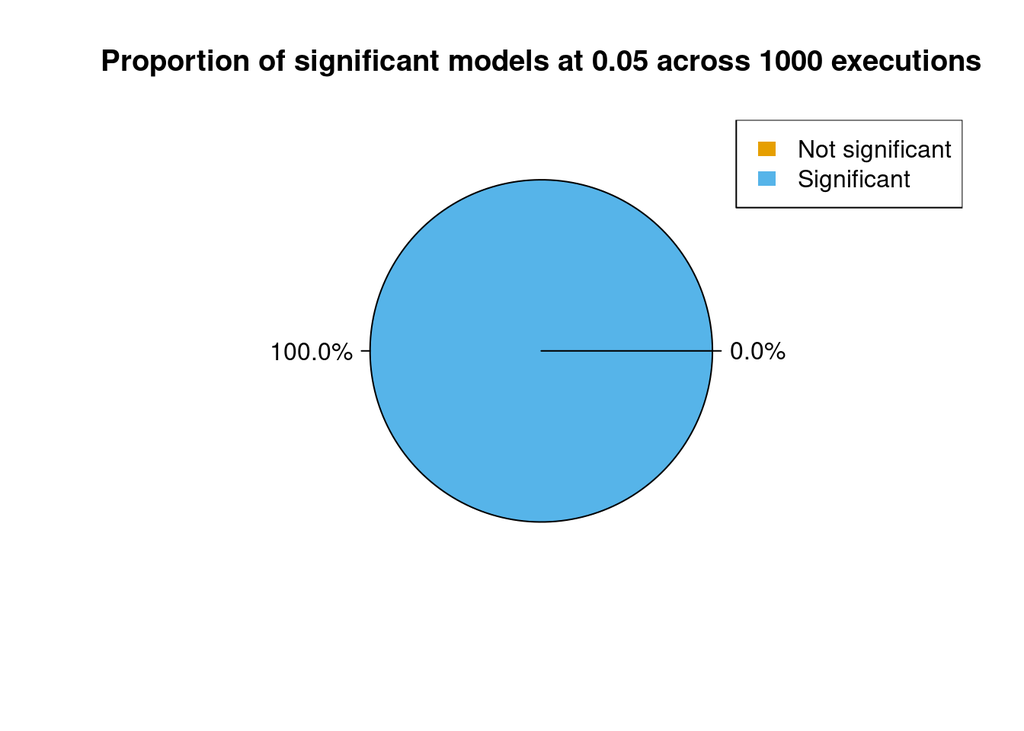

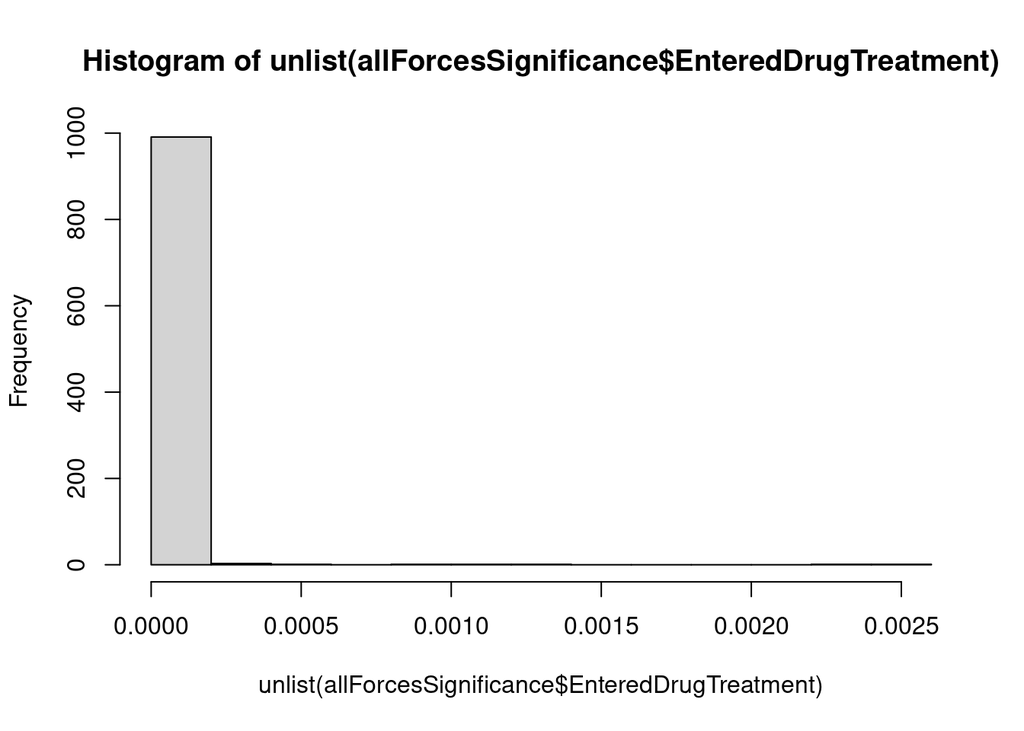

```
##      Min.   1st Qu.    Median      Mean   3rd Qu.      Max.
## 0.000e+00 0.000e+00 1.800e-09 1.252e-05 8.700e-08 2.459e-03
```

#### 3.2.0.5 Most significant model

```
## Length  Class   Mode
##      0   NULL   NULL
```

#### 3.2.0.6 Least significant model

```
## Length  Class   Mode
##      0   NULL   NULL
```

### HospitalEventCount

#### 3.2.0.7 Significance proportions

The figure below shows the histogram of the UsesPDD fixed effect significance:

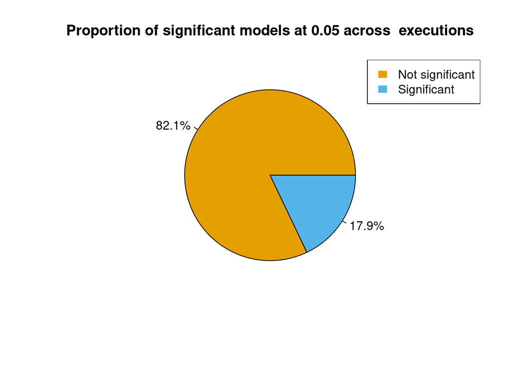

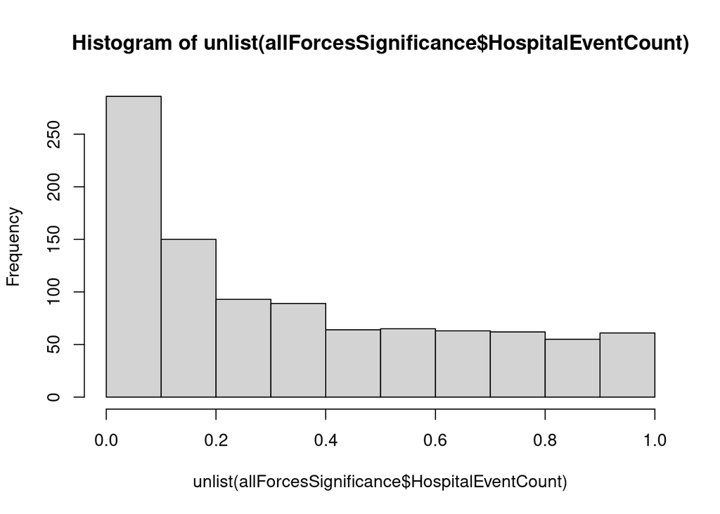

```
##     Min.  1st Qu.   Median     Mean  3rd Qu.     Max.     NA's
## 0.000006 0.083085 0.264618 0.348240 0.593141 0.996451       12
```

#### 3.2.0.8 Most significant model

```
## Length  Class   Mode
##      0   NULL   NULL
```

#### 3.2.0.9 Least significant model

```
## Length  Class   Mode
##      0   NULL   NULL
```

The assumptions are identical to the previous baseline model described but we only use the first 6 police forces: PF1 - PF6

## 3.3 Results First6Forces

### ReoffendedWithinYear

#### 3.3.0.1 Significance proportions

The figure below shows the histogram of the UsesPDD fixed effect significance:

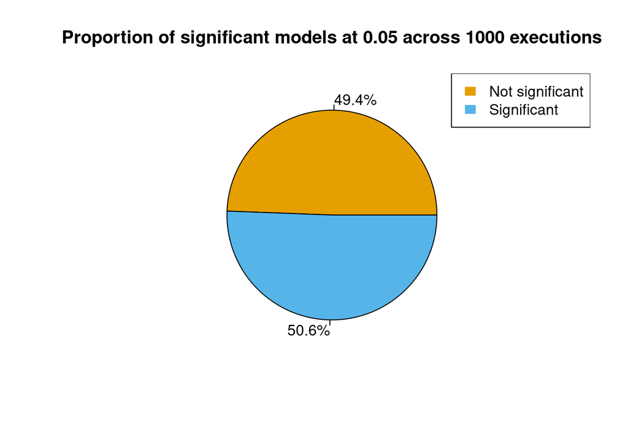

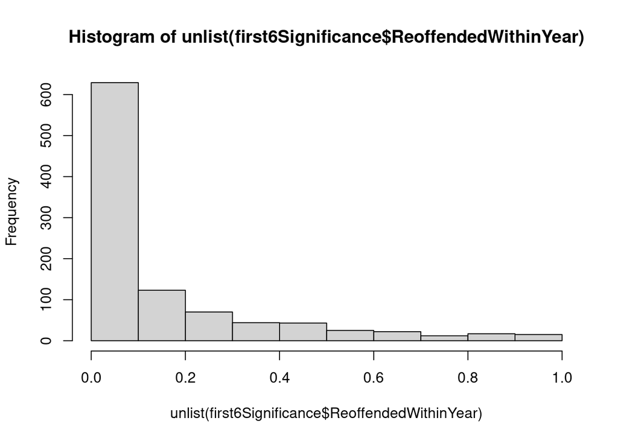

```
##      Min.   1st Qu.    Median      Mean   3rd Qu.      Max.
## 0.0000007 0.0094220 0.0490596 0.1509523 0.1972030 0.9944058
```

#### 3.3.0.2 Most significant model

```
## Length  Class   Mode
##      0   NULL   NULL
```

#### 3.3.0.3 Least significant model

```
## Length  Class   Mode
##      0   NULL   NULL
```

### EnteredDrugTreatment

#### 3.3.0.4 Significance proportions

The figure below shows the histogram of the UsesPDD fixed effect significance:

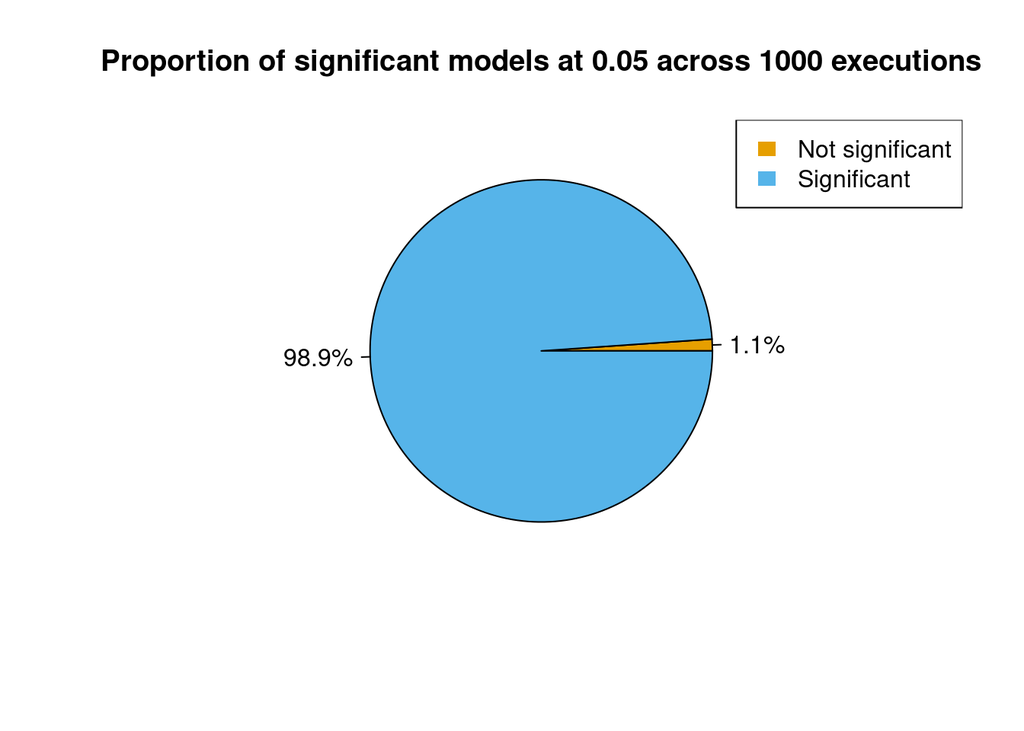

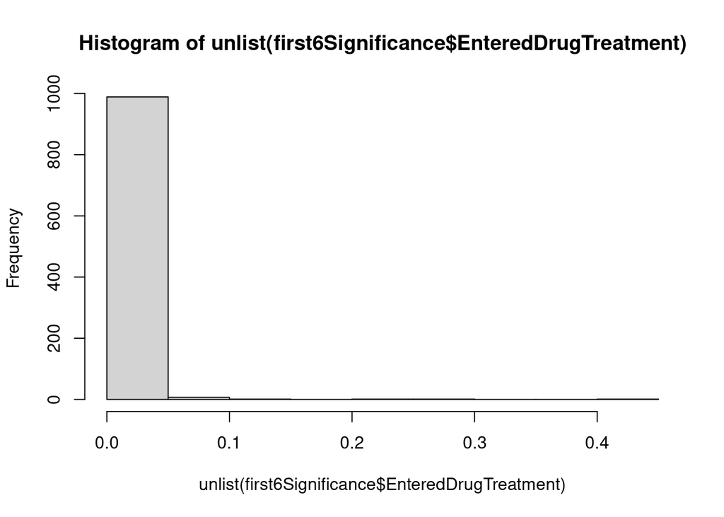

```
##      Min.   1st Qu.    Median      Mean   3rd Qu.      Max.
## 0.0000000 0.0000013 0.0000296 0.0032084 0.0004936 0.4348065
```

#### 3.3.0.5 Most significant model

```
## Length  Class   Mode
##      0   NULL   NULL
```

#### 3.3.0.6 Least significant model

```
## Length  Class   Mode
##      0   NULL   NULL
```

### HospitalEventCount

#### 3.3.0.7 Significance proportions

The figure below shows the histogram of the UsesPDD fixed effect significance:

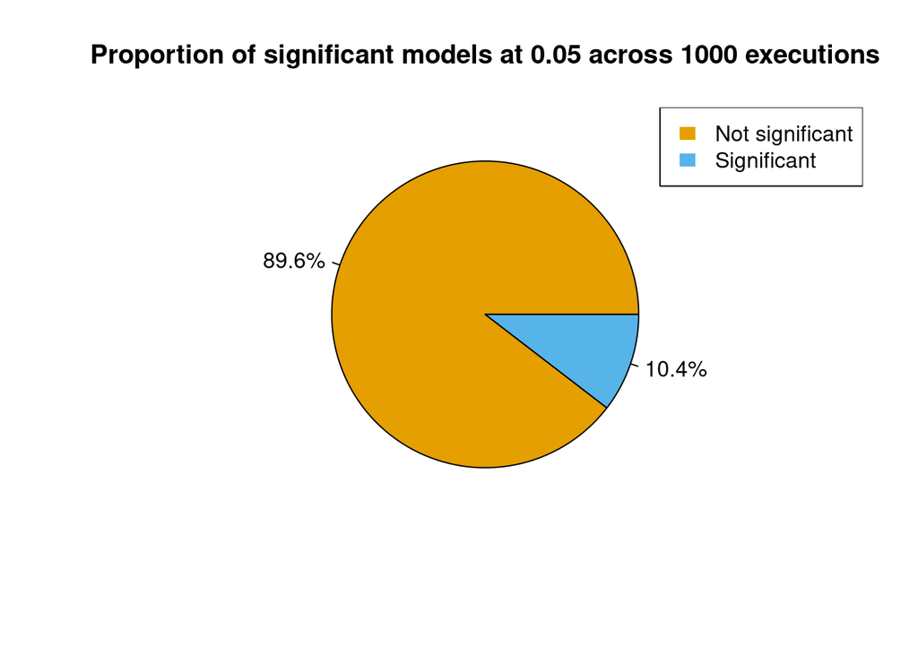

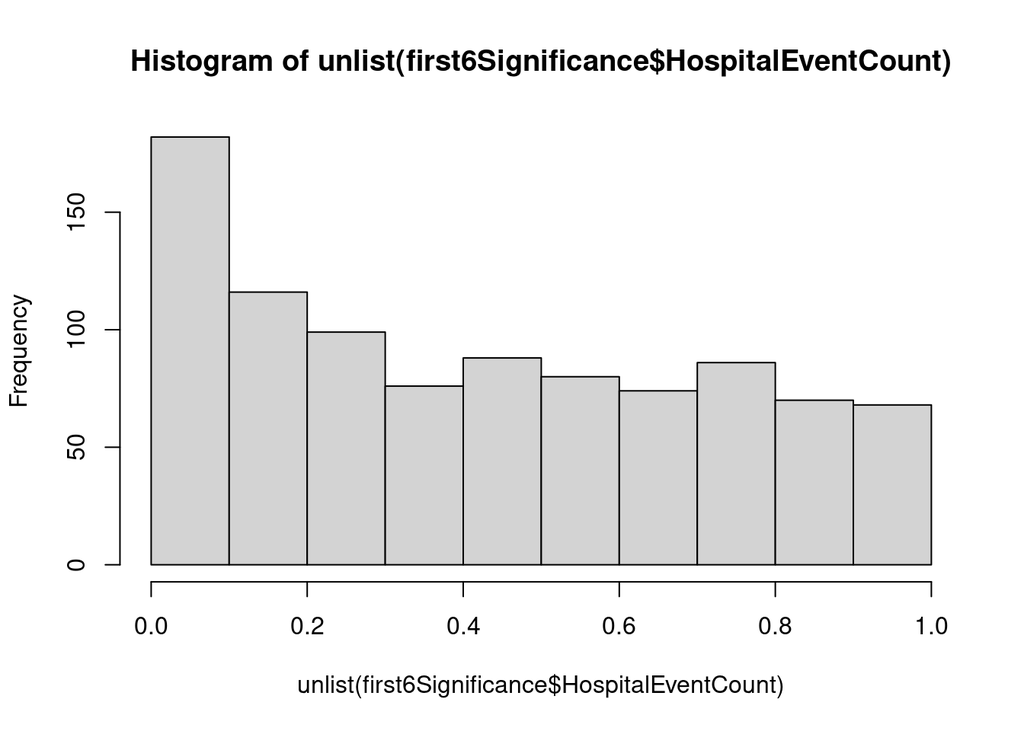

```
##    Min. 1st Qu.  Median    Mean 3rd Qu.    Max.    NA's
## 0.00023 0.14431 0.39295 0.42513 0.68656 0.99991      61
```

#### 3.3.0.8 Most significant model

```
## Length  Class   Mode
##      0   NULL   NULL
```

#### 3.3.0.9 Least significant model

```
## Length  Class   Mode
##      0   NULL   NULL
```